# AIM-AHEAD Project

Virutal twins model Stage 1 and 2 for subgroup identification of disparities

Wanru Guo and Cici Bauer

Last compiled on November 29, 2024

## Virtual twins stage 1

```r
library(data.table)
library(ggplot2)
library(dplyr)
library(gridExtra)
library(png)
library(grid)
```

### Function to train models and evaluate performance

```r
evaluate_models <- function(dataset_h2o, predictors, outcome) {

  # Convert the outcome to factor (for classification tasks)
  dataset_h2o[, outcome] <- as.factor(dataset_h2o[, outcome])

  # Logistic Regression
  logit_model <- h2o.glm(
    x = predictors,
    y = outcome,
    training_frame = dataset_h2o,
    family = "binomial",
    nfolds = 10,
    seed = 1234
  )

  # Random Forest
  rf_model <- h2o.randomForest(
    x = predictors,
    y = outcome,
    training_frame = dataset_h2o,
    nfolds = 10,
    seed = 1234
  )

  # GBM
  gbm_model <- h2o.gbm(
    x = predictors,
    y = outcome,
    training_frame = dataset_h2o,
    nfolds = 10,
    seed = 1234
  )

  # Decision Tree (using H2O's Decision Tree)
  dt_model <- h2o.naiveBayes(  # Assuming Naive Bayes is replaced by DT if available
    x = predictors,
    y = outcome,
    training_frame = dataset_h2o,
    nfolds = 10,
    seed = 1234
  )

  # Neural Network (MLP with two hidden layers)
  nn_model <- h2o.deeplearning(
    x = predictors,
    y = outcome,
    training_frame = dataset_h2o,
    hidden = c(64, 64),
    activation = "RectifierWithDropout",
    nfolds = 10,
    seed = 1234
  )

  # Get Performance for each model at threshold = 0.5
  get_metrics <- function(model, dataset) {
    perf <- h2o.performance(model, dataset)
    auc <- h2o.auc(perf)
    aucpr <- h2o.aucpr(perf)

    # Get metrics at threshold = 0.5
    threshold_0.5 <- 0.5
    accuracy <- h2o.accuracy(perf, thresholds = threshold_0.5)
    precision <- h2o.precision(perf, thresholds = threshold_0.5)
    recall <- h2o.recall(perf, thresholds = threshold_0.5)
    f1 <- h2o.F1(perf, thresholds = threshold_0.5)

    list(auc = auc, aucpr = aucpr, precision = precision, recall = recall, accuracy = accuracy, f1 = f1)
  }

  # Store metrics for each model
  metrics <- list(
    logistic = get_metrics(logit_model, dataset_h2o),
    random_forest = get_metrics(rf_model, dataset_h2o),
    gbm = get_metrics(gbm_model, dataset_h2o),
    decision_tree = get_metrics(dt_model, dataset_h2o),
    neural_network = get_metrics(nn_model, dataset_h2o)
  )

  # Extract ROC and PR curves data for each model
  fpr_logit <- as.data.frame(h2o.fpr(h2o.performance(logit_model, dataset_h2o)))
  tpr_logit <- as.data.frame(h2o.tpr(h2o.performance(logit_model, dataset_h2o)))
  fpr_rf <- as.data.frame(h2o.fpr(h2o.performance(rf_model, dataset_h2o)))
  tpr_rf <- as.data.frame(h2o.tpr(h2o.performance(rf_model, dataset_h2o)))
  fpr_gbm <- as.data.frame(h2o.fpr(h2o.performance(gbm_model, dataset_h2o)))
  tpr_gbm <- as.data.frame(h2o.tpr(h2o.performance(gbm_model, dataset_h2o)))
  fpr_dt <- as.data.frame(h2o.fpr(h2o.performance(dt_model, dataset_h2o)))
  tpr_dt <- as.data.frame(h2o.tpr(h2o.performance(dt_model, dataset_h2o)))
  fpr_nn <- as.data.frame(h2o.fpr(h2o.performance(nn_model, dataset_h2o)))
  tpr_nn <- as.data.frame(h2o.tpr(h2o.performance(nn_model, dataset_h2o)))

  auc_logit <- round(h2o.auc(h2o.performance(logit_model, dataset_h2o)), 3)
auc_rf <- round(h2o.auc(h2o.performance(rf_model, dataset_h2o)), 3)
auc_gbm <- round(h2o.auc(h2o.performance(gbm_model, dataset_h2o)), 3)
auc_dt <- round(h2o.auc(h2o.performance(dt_model, dataset_h2o)), 3)
auc_nn <- round(h2o.auc(h2o.performance(nn_model, dataset_h2o)), 3)

  # Combine ROC data for ggplot
  roc_data <- rbind(
  data.frame(FPR = fpr_logit$fpr, TPR = tpr_logit$tpr, Model = paste("Logistic Regression (AUC:", auc_logit, ")")),
  data.frame(FPR = fpr_rf$fpr, TPR = tpr_rf$tpr, Model = paste("Random Forest (AUC:", auc_rf, ")")),
  data.frame(FPR = fpr_gbm$fpr, TPR = tpr_gbm$tpr, Model = paste("GBM (AUC:", auc_gbm, ")")),
  data.frame(FPR = fpr_dt$fpr, TPR = tpr_dt$tpr, Model = paste("Decision Tree (AUC:", auc_dt, ")")),
  data.frame(FPR = fpr_nn$fpr, TPR = tpr_nn$tpr, Model = paste("Neural Network (AUC:", auc_nn, ")"))
)

  # Plot ROC curves
  roc_plot <- ggplot(roc_data, aes(x = FPR, y = TPR, color = Model)) +
    geom_line(size = 1.2) +
    labs(title = "ROC Curve", x = "False Positive Rate (FPR)", y = "True Positive Rate (TPR)") +
    theme_minimal() +
    scale_color_manual(values = c("blue", "red", "green", "purple", "orange")) +
    theme(legend.position = c(0.8, 0.2))  # Legend inside

  # Combine PR data for ggplot
  precision_logit <- h2o.precision(h2o.performance(logit_model, dataset_h2o))
  recall_logit <- h2o.recall(h2o.performance(logit_model, dataset_h2o))
  precision_rf <- h2o.precision(h2o.performance(rf_model, dataset_h2o))
  recall_rf <- h2o.recall(h2o.performance(rf_model, dataset_h2o))
  precision_gbm <- h2o.precision(h2o.performance(gbm_model, dataset_h2o))
  recall_gbm <- h2o.recall(h2o.performance(gbm_model, dataset_h2o))
  precision_dt <- h2o.precision(h2o.performance(dt_model, dataset_h2o))
  recall_dt <- h2o.recall(h2o.performance(dt_model, dataset_h2o))
  precision_nn <- h2o.precision(h2o.performance(nn_model, dataset_h2o))
  recall_nn <- h2o.recall(h2o.performance(nn_model, dataset_h2o))

  aucpr_logit <- round(h2o.aucpr(h2o.performance(logit_model, dataset_h2o)), 3)
aucpr_rf <- round(h2o.aucpr(h2o.performance(rf_model, dataset_h2o)), 3)
aucpr_gbm <- round(h2o.aucpr(h2o.performance(gbm_model, dataset_h2o)), 3)
aucpr_dt <- round(h2o.aucpr(h2o.performance(dt_model, dataset_h2o)), 3)
aucpr_nn <- round(h2o.aucpr(h2o.performance(nn_model, dataset_h2o)), 3)

  pr_data <- rbind(
  data.frame(Recall = recall_logit$tpr, Precision = precision_logit$precision, Model = paste("Logistic Regression (AUCPR:", aucpr_logit, ")")),
  data.frame(Recall = recall_rf$tpr, Precision = precision_rf$precision, Model = paste("Random Forest (AUCPR:", aucpr_rf, ")")),
  data.frame(Recall = recall_gbm$tpr, Precision = precision_gbm$precision, Model = paste("GBM (AUCPR:", aucpr_gbm, ")")),
  data.frame(Recall = recall_dt$tpr, Precision = precision_dt$precision, Model = paste("Decision Tree (AUCPR:", aucpr_dt, ")")),
  data.frame(Recall = recall_nn$tpr, Precision = precision_nn$precision, Model = paste("Neural Network (AUCPR:", aucpr_nn, ")"))
)

  # Plot PR curves
  pr_plot <- ggplot(pr_data, aes(x = Recall, y = Precision, color = Model)) +
    geom_line(size = 1.2) +
    labs(title = "Precision-Recall Curve", x = "Recall", y = "Precision") +
    theme_minimal() +
    scale_color_manual(values = c("blue", "red", "green", "purple", "orange")) +
    theme(legend.position = c(0.8, 0.2))  # Legend inside

  # Return the metrics and the plots
  return(list(metrics = metrics, roc_plot = roc_plot, pr_plot = pr_plot))
}
```

```r
episode_model1_h2o <- as.h2o(episode_model1)
episode_model2_h2o <- as.h2o(episode_model2)
episode_model3_h2o <- as.h2o(episode_model3)
```

### Prediction performance with Baseline predictors

```r
library(knitr)
library(kableExtra)

# Example data frame
model_performance <- data.frame(
  Model = c("Logistic Regression", "Random Forest", "Gradient Boosting Machine", "Decision Tree", "Neural Network"),
  AUC = c(0.6023115, 0.7596246, 0.6220612, 0.5914425, 0.6082684),
  AUCPR = c(0.8408238, 0.9180073, 0.8528537, 0.8332558, 0.8452299),
  Precision = c(0.7811489, 0.786141, 0.7811489, 0.7811489, 0.7811489),
  Recall = c(1.0, 0.9994873, 1.0, 1.0, 1.0),
  Accuracy = c(0.7811489, 0.7872075, 0.7811489, 0.7811489, 0.7811489),
  `F1 Score` = c(0.8771292, 0.8800689, 0.8771292, 0.8771292, 0.8771292)
)

# Create and save the table
kable(model_performance, caption = "Model Performance Metrics with Baseline Predictors", digits = 4, format = "html") %>%
  kable_styling(full_width = FALSE, bootstrap_options = c("striped", "hover", "condensed")) %>%
  save_kable("model_performance_metrics.html")

model_performance
```

| Model | AUC | AUCPR | Precision | Recall | Accuracy | F1.Score |
| --- | --- | --- | --- | --- | --- | --- |
| Logistic Regression | 0.6023115 | 0.8408238 | 0.7811489 | 1.0000000 | 0.7811489 | 0.8771292 |
| Random Forest | 0.7596246 | 0.9180073 | 0.7861410 | 0.9994873 | 0.7872075 | 0.8800689 |
| Gradient Boosting Machine | 0.6220612 | 0.8528537 | 0.7811489 | 1.0000000 | 0.7811489 | 0.8771292 |
| Decision Tree | 0.5914425 | 0.8332558 | 0.7811489 | 1.0000000 | 0.7811489 | 0.8771292 |
| Neural Network | 0.6082684 | 0.8452299 | 0.7811489 | 1.0000000 | 0.7811489 | 0.8771292 |

```r
img1 <- readPNG("results1_roc.png")
img2 <- readPNG("results1_pr.png")
```

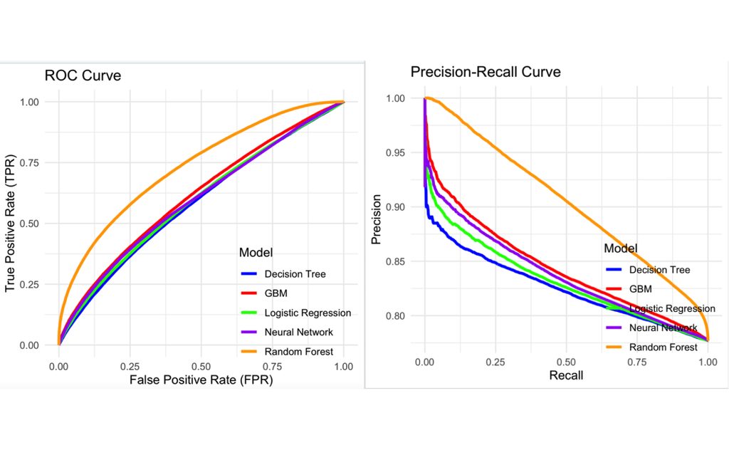

```r
# Convert images to grid objects
g1 <- rasterGrob(img1, interpolate = TRUE)
g2 <- rasterGrob(img2, interpolate = TRUE)

# Display images side by side
grid.arrange(g1, g2, ncol = 2)
```

### Prediction performance with Baseline predictors + integrating with socioeconomical (community-level) Predictors

```r
# Example usage
predictors <- setdiff(names(episode_model2_h2o), "discontinued")
outcome <- "discontinued"
results2 <- evaluate_models(episode_model2_h2o, predictors, outcome)
```

saveRDS(results2, file = “results2.rds”) results2<-readRDS(“results2.rds”)

```r
metrics_table <- do.call(rbind, lapply(results2$metrics, function(model) {
  data.frame(
    auc = model$auc,
    aucpr = model$aucpr,
    precision = model$precision[[1]],
    recall = model$recall[[1]],
    accuracy = model$accuracy[[1]],
    f1 = model$f1[[1]]
  )
}))

# Add model names as a column
metrics_table <- cbind(Model = names(results2$metrics), metrics_table)

# Display the table
library(knitr)
kable(metrics_table, caption = "Model Performance with Baseline + socioecomonical predictors ")
```

Model Performance with Baseline + socioecomonical predictors

|  | Model | auc | aucpr | precision | recall | accuracy | f1 |
| --- | --- | --- | --- | --- | --- | --- | --- |
| logistic | logistic | 0.6090917 | 0.8439331 | 0.7812254 | 0.9995111 | 0.7809719 | 0.8769893 |
| random_forest | random_forest | 0.8500993 | 0.9521515 | 0.7932501 | 0.9987838 | 0.7957017 | 0.8842303 |
| gbm | gbm | 0.6305626 | 0.8565560 | 0.7811489 | 1.0000000 | 0.7811489 | 0.8771292 |
| decision_tree | decision_tree | 0.5984992 | 0.8367449 | 0.7812705 | 0.9990938 | 0.7807949 | 0.8768571 |
| neural_network | neural_network | 0.6135159 | 0.8478948 | 0.7811489 | 1.0000000 | 0.7811489 | 0.8771292 |

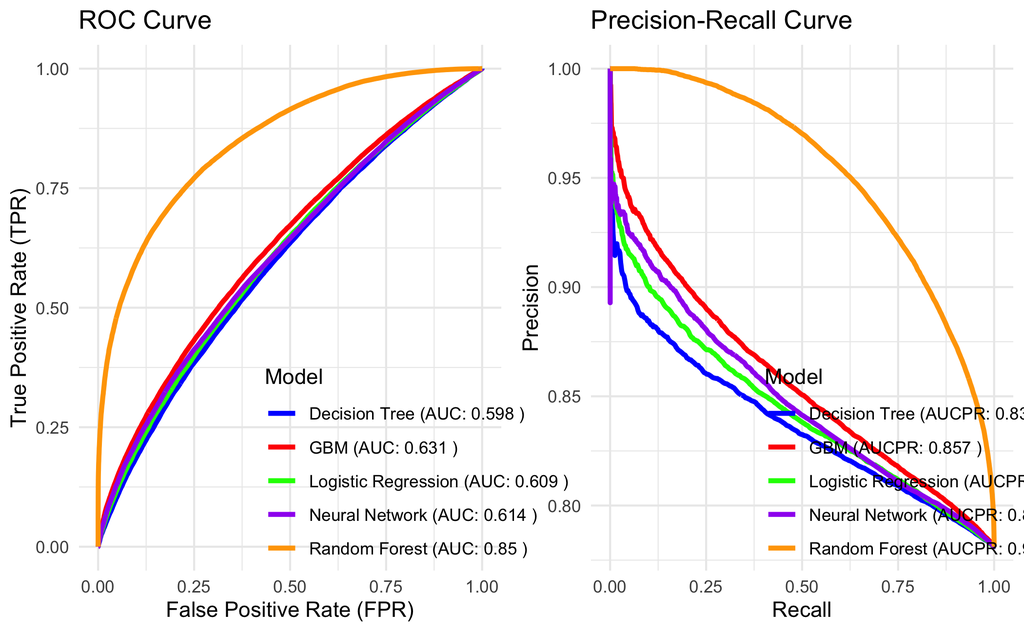

```r
library(gridExtra)

# Display the two plots side by side
grid.arrange(results2$roc_plot, results2$pr_plot, ncol = 2)
```

### Prediction performance with Baseline predictors + integrating with socioeconomical (community-level) + pdc90 Predictors

```r
# Example usage
predictors <- setdiff(names(episode_model3_h2o), "discontinued")
outcome <- "discontinued"
results3 <- evaluate_models(episode_model3_h2o, predictors, outcome)
```

saveRDS(results3, file = “results3.rds”) results3<-readRDS(“results3.rds”)

```r
metrics_table <- do.call(rbind, lapply(results3$metrics, function(model) {
  data.frame(
    auc = model$auc,
    aucpr = model$aucpr,
    precision = model$precision[[1]],
    recall = model$recall[[1]],
    accuracy = model$accuracy[[1]],
    f1 = model$f1[[1]]
  )
}))

# Add model names as a column
metrics_table <- cbind(Model = names(results3$metrics), metrics_table)

# Display the table
library(knitr)
kable(metrics_table, caption = "Model Performance with Baseline + socioecomonical + pdc90 predictors ")
```

Model Performance with Baseline + socioecomonical + pdc90 predictors

|  | Model | auc | aucpr | precision | recall | accuracy | f1 |
| --- | --- | --- | --- | --- | --- | --- | --- |
| logistic | logistic | 0.7657703 | 0.9146681 | 0.7829156 | 0.9945511 | 0.7803292 | 0.8761341 |
| random_forest | random_forest | 0.8929084 | 0.9675174 | 0.8349473 | 0.9874270 | 0.8377023 | 0.9048081 |
| gbm | gbm | 0.7789406 | 0.9227588 | 0.7817004 | 0.9991356 | 0.7813677 | 0.8771439 |
| decision_tree | decision_tree | 0.7616291 | 0.9101206 | 0.8189876 | 0.9061643 | 0.7702517 | 0.8603733 |
| neural_network | neural_network | 0.7706413 | 0.9190399 | 0.7811489 | 1.0000000 | 0.7811489 | 0.8771292 |

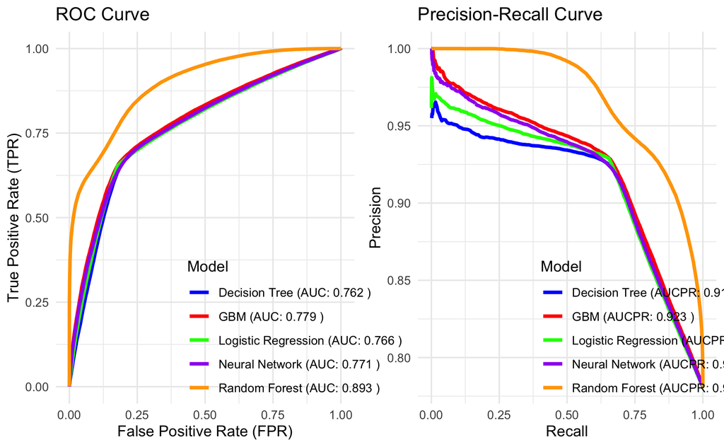

```r
library(gridExtra)

# Display the two plots side by side
grid.arrange(results3$roc_plot, results3$pr_plot, ncol = 2)
```

### Prediction Performance of model3 (baseline+socioeconomic+pdc90) after SMOTE (oversampling the minority class)

library(ggplot2) library(dplyr)

```r
evaluate_models2 <- function(dataset_h2o, predictors, outcome = "discontinued") {
    # Convert the outcome to factor (for classification tasks)
    dataset_h2o[, outcome] <- as.factor(dataset_h2o[, outcome])

    # Set common parameters for SMOTE-like class balancing
    balance_params <- list(balance_classes = TRUE, class_sampling_factors = c(1.0, 3.57))  # 3.57 approximates the imbalance

    # Logistic Regression
    logit_model <- h2o.glm(
      x = predictors,
      y = outcome,
      training_frame = dataset_h2o,
      family = "binomial",
      nfolds = 10,
      seed = 1234,
      balance_classes = balance_params$balance_classes,
      class_sampling_factors = balance_params$class_sampling_factors  # Apply class balancing parameters
    )

    # Random Forest
    rf_model <- h2o.randomForest(
      x = predictors,
      y = outcome,
      training_frame = dataset_h2o,
      nfolds = 10,
      seed = 1234,
      balance_classes = balance_params$balance_classes,
      class_sampling_factors = balance_params$class_sampling_factors
    )

    # GBM
    gbm_model <- h2o.gbm(
      x = predictors,
      y = outcome,
      training_frame = dataset_h2o,
      nfolds = 10,
      seed = 1234,
      balance_classes = balance_params$balance_classes,
      class_sampling_factors = balance_params$class_sampling_factors
    )

    # Neural Network (MLP with two hidden layers)
    nn_model <- h2o.deeplearning(
      x = predictors,
      y = outcome,
      training_frame = dataset_h2o,
      hidden = c(64, 64),
      activation = "RectifierWithDropout",
      nfolds = 10,
      seed = 1234,
      balance_classes = balance_params$balance_classes,
      class_sampling_factors = balance_params$class_sampling_factors
    )


    # Get Performance for each model at threshold = 0.5
    get_metrics <- function(model, dataset) {
      perf <- h2o.performance(model, dataset)
      auc <- h2o.auc(perf)
      aucpr <- h2o.aucpr(perf)

      # Get metrics at threshold = 0.5
      threshold_0.5 <- 0.5
      accuracy <- h2o.accuracy(perf, thresholds = threshold_0.5)
      precision <- h2o.precision(perf, thresholds = threshold_0.5)
      recall <- h2o.recall(perf, thresholds = threshold_0.5)
      f1 <- h2o.F1(perf, thresholds = threshold_0.5)

      list(auc = auc, aucpr = aucpr, precision = precision, recall = recall, accuracy = accuracy, f1 = f1)
    }

    # Store metrics for each model
    metrics <- list(
      logistic = get_metrics(logit_model, dataset_h2o),
      random_forest = get_metrics(rf_model, dataset_h2o),
      gbm = get_metrics(gbm_model, dataset_h2o),
      neural_network = get_metrics(nn_model, dataset_h2o)
    )

    # Extract ROC and PR curves data for each model
    fpr_logit <- as.data.frame(h2o.fpr(h2o.performance(logit_model, dataset_h2o)))
    tpr_logit <- as.data.frame(h2o.tpr(h2o.performance(logit_model, dataset_h2o)))
    fpr_rf <- as.data.frame(h2o.fpr(h2o.performance(rf_model, dataset_h2o)))
    tpr_rf <- as.data.frame(h2o.tpr(h2o.performance(rf_model, dataset_h2o)))
    fpr_gbm <- as.data.frame(h2o.fpr(h2o.performance(gbm_model, dataset_h2o)))
    tpr_gbm <- as.data.frame(h2o.tpr(h2o.performance(gbm_model, dataset_h2o)))
    fpr_nn <- as.data.frame(h2o.fpr(h2o.performance(nn_model, dataset_h2o)))
    tpr_nn <- as.data.frame(h2o.tpr(h2o.performance(nn_model, dataset_h2o)))

    # Combine ROC data for ggplot
    roc_data <- rbind(
      data.frame(FPR = fpr_logit$fpr, TPR = tpr_logit$tpr, Model = "Logistic Regression"),
      data.frame(FPR = fpr_rf$fpr, TPR = tpr_rf$tpr, Model = "Random Forest"),
      data.frame(FPR = fpr_gbm$fpr, TPR = tpr_gbm$tpr, Model = "GBM"),
      data.frame(FPR = fpr_nn$fpr, TPR = tpr_nn$tpr, Model = "Neural Network")
    )

    # Plot ROC curves
    roc_plot <- ggplot(roc_data, aes(x = FPR, y = TPR, color = Model)) +
      geom_line(size = 1.2) +
      labs(title = "ROC Curve", x = "False Positive Rate (FPR)", y = "True Positive Rate (TPR)") +
      theme_minimal() +
      scale_color_manual(values = c("blue", "red", "green", "orange")) +
      theme(legend.position = c(0.8, 0.2))  # Legend inside

    # Combine PR data for ggplot
    precision_logit <- h2o.precision(h2o.performance(logit_model, dataset_h2o))
    recall_logit <- h2o.recall(h2o.performance(logit_model, dataset_h2o))
    precision_rf <- h2o.precision(h2o.performance(rf_model, dataset_h2o))
    recall_rf <- h2o.recall(h2o.performance(rf_model, dataset_h2o))
    precision_gbm <- h2o.precision(h2o.performance(gbm_model, dataset_h2o))
    recall_gbm <- h2o.recall(h2o.performance(gbm_model, dataset_h2o))
    precision_nn <- h2o.precision(h2o.performance(nn_model, dataset_h2o))
    recall_nn <- h2o.recall(h2o.performance(nn_model, dataset_h2o))

    pr_data <- rbind(
      data.frame(Recall = recall_logit$tpr, Precision = precision_logit$precision, Model = "Logistic Regression"),
      data.frame(Recall = recall_rf$tpr, Precision = precision_rf$precision, Model = "Random Forest"),
      data.frame(Recall = recall_gbm$tpr, Precision = precision_gbm$precision, Model = "GBM"),
      data.frame(Recall = recall_nn$tpr, Precision = precision_nn$precision, Model = "Neural Network")
    )

    # Plot PR curves
    pr_plot <- ggplot(pr_data, aes(x = Recall, y = Precision, color = Model)) +
      geom_line(size = 1.2) +
      labs(title = "Precision-Recall Curve", x = "Recall", y = "Precision") +
      theme_minimal() +
      scale_color_manual(values = c("blue", "red", "green", "orange")) +
      theme(legend.position = c(0.8, 0.2))  # Legend inside

    # Return the metrics and the plots
    return(list(metrics = metrics, roc_plot = roc_plot, pr_plot = pr_plot))
}
```

```r
# Example usage
predictors <- setdiff(names(episode_model3_h2o), "discontinued")
outcome <- "discontinued"
results4 <- evaluate_models2(episode_model3_h2o, predictors, outcome)
```

saveRDS(results4, file = “results4.rds”)

```r
library(gridExtra)

# Display the two plots side by side
grid.arrange(results4$roc_plot, results4$pr_plot, ncol = 2)
```

[output not shown]

## Virtual Twins Stage 2

```r
library(rpart)
library(rpart.plot)
```

### Function for stage 2

```r
# Define the function
virtual_twins_analysis <- function(dataset, outcome, disparity_var, predictors1, predictors2) {
  # Step 1: Convert the dataset to H2O format
  dataset_h2o <- as.h2o(dataset)

  # Split the dataset into 20% training and 80% testing
  splits <- h2o.splitFrame(data = dataset_h2o, ratios = 0.2, seed = 1234)
  train <- splits[[1]]  # 20% for training
  test <- splits[[2]]   # 80% for testing

  # Step 2: Train the Random Forest model using the training data
  rf_model_h2o <- h2o.randomForest(
    x = predictors1,
    y = outcome,
    training_frame = train,
    nfolds = 10,  # 10-fold cross-validation
    seed = 1234   # For reproducibility
  )

##h2o.varimp_plot(rf_model2_h2o, num_of_features = 20)

  # Step 3: Create two test datasets with "Low" and "High" disparity values
  data_L <- test
  data_H <- test
  data_L <- data_H <- h2o.assign(data_L, "data_L_h2o")
 # Set "0" and "1" disparity values as factors for both datasets
data_L[disparity_var] <- "0"
data_H[disparity_var] <- "1"
##data_H1<-as.data.frame(data_H)
##table(data_H1$der_sex)

data_L <- data_L[, !names(data_L) %in% outcome]
data_H <- data_H[, !names(data_H) %in% outcome]

  # Step 4: Predict probabilities for both datasets (Low and High disparity)
  pred_L <- h2o.predict(rf_model_h2o, data_L)
  pred_H <- h2o.predict(rf_model_h2o, data_H)

  # Convert predictions to data frames and extract probabilities
  probs_L <- as.data.frame(pred_L)$p1  # Assuming p1 is the probability of the positive class
  probs_H <- as.data.frame(pred_H)$p1

  # Step 5: Calculate Z = Prf(High) - Prf(Low)
  Z <- probs_H - probs_L

data_for_tree <- test
data_for_tree$Z <- as.h2o(Z)

data_for_tree<-as.data.frame(data_for_tree)
  data_for_tree <- data_for_tree[, !names(data_for_tree) %in% c(outcome, disparity_var)]

  # Step 7: Fit a regression tree with Z as the outcome and predictors as the features
  formula <- as.formula(paste("Z ~", paste(predictors2, collapse = " + ")))

  # Return the data_for_tree data frame and the formula for tree building
return(list(data_for_tree = data_for_tree, formula = formula))
}
```

### Sex Disparities (Z = Prf(Sex=F, Xi) - Prf (Sex=M, Xi))

```r
predictors1<- setdiff(names(episode_model33), "discontinued")
predictors2 <- c("pat_region", "age_group", "m_health", "nodrug", "alcohol", "svi", "telehealth", "induction", "outpatient", "bupre_tx", "hiv", "mat", "pay_type", "psychiatric")
outcome <- "discontinued"
disparity_var <- "der_sex"
```

```r
# Call the function with the dataset and parameters
s2_result <- virtual_twins_analysis(
  dataset = episode_model34,
  outcome = outcome,
  disparity_var = disparity_var,
  predictors1 = predictors1,
  predictors2 = predictors2
)
data_for_tree <- s2_result$data_for_tree
formula <- s2_result$formula

#par(mfrow = c(1, 2))
tree_model <- rpart(
  formula,
  data = data_for_tree,
  method = "anova",
  control = rpart.control(
    minsplit = 75,  # Higher number to reduce splits
    cp = 0.002,      # Higher cp for aggressive pruning
    maxdepth = 3,   # Limit tree depth to 3 levels
    maxcompete = 0, # Prevent competing splits, to make splitting more strict
    maxsurrogate = 0 # Avoid using surrogate splits
  )
)
```

tree_model_sex1<-readRDS(“tree_model_sex1.rds”)

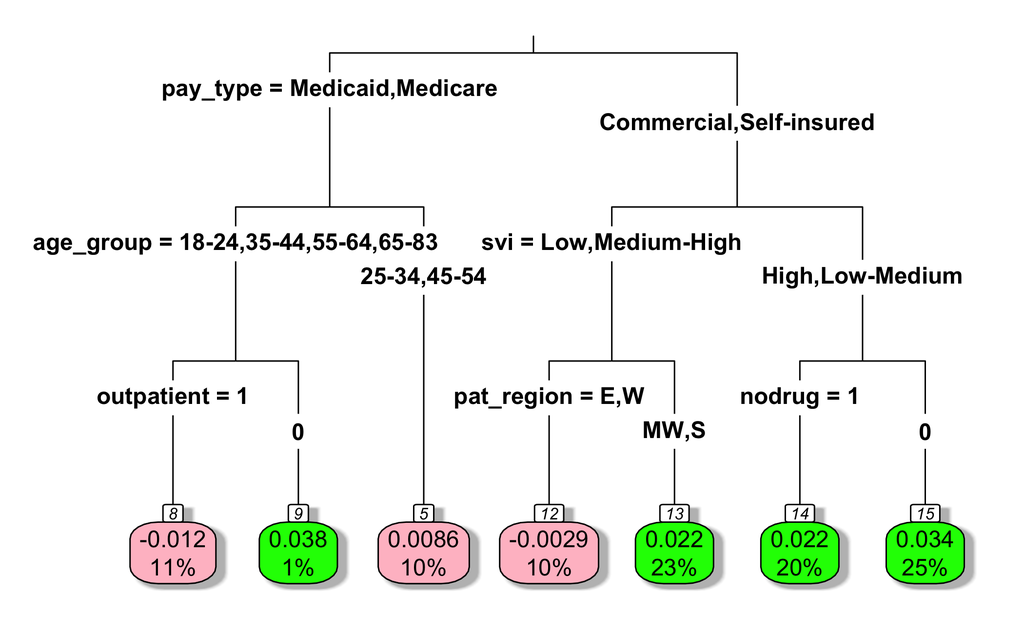

```r
library(rpart.plot)
library(rpart)
#rpart.plot(tree_model, type = 3, box.palette = "RdBu", shadow.col = "gray", nn = TRUE)
rpart.plot(
  tree_model_sex,
  type = 3,
  box.palette = c("pink", "green"),  # Custom palette: pink and green
  shadow.col = "gray",
  nn = TRUE
)
```

tree_model_sex1<-tree_model saveRDS(tree_model_sex1, file = “tree_model_sex1.rds”) saveRDS(tree_model, file = “tree_model_sex.rds”)

dont forget to save tree_model_sex<-tree_model

### SVI type disparities (Z = Prf(SVI=High, Xi)-Prf (SVI=Low, Xi))

```r
predictors1<- setdiff(names(episode_model33), "discontinued")

predictors2 <- c("pat_region", "age_group", "m_health", "nodrug", "alcohol", "der_sex", "telehealth", "induction", "outpatient", "bupre_tx", "hiv", "mat", "pay_type", "psychiatric")
outcome <- "discontinued"
disparity_var <- "svi"

s2_result <- virtual_twins_analysis(
  dataset = episode_model4,
  outcome = outcome,
  disparity_var = disparity_var,
  predictors1 = predictors1,
  predictors2 = predictors2
)
data_for_tree <- s2_result$data_for_tree
formula <- s2_result$formula

tree_model_svi <- rpart(
  formula,
  data = data_for_tree,
  method = "anova",
  control = rpart.control(
    minsplit = 100,  # Higher number to reduce splits
    cp = 0.005,      # Higher cp for aggressive pruning
    maxdepth = 4,   # Limit tree depth to 3 levels
    maxcompete = 0, # Prevent competing splits, to make splitting more strict
    maxsurrogate = 0 # Avoid using surrogate splits
  )
)
```

tree_model_svi1<-readRDS(“tree_model_svi1.rds”)

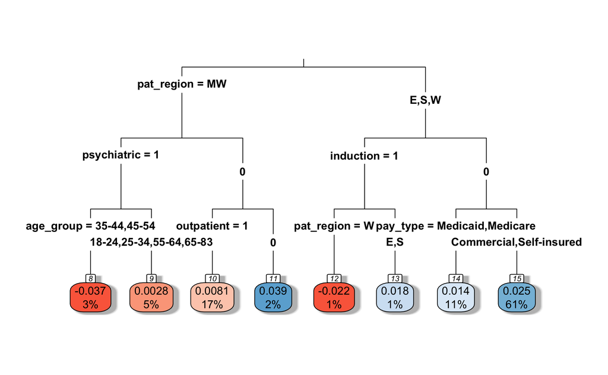

```r
rpart.plot(tree_model_svi3, type = 3, box.palette = "RdBu", shadow.col = "gray", nn = TRUE, roundint=FALSE)
```

saveRDS(tree_model_svi3, file = “tree_model_svi3.rds”) saveRDS(tree_model_svi1, file = “tree_model_svi1.rds”) #very big tree saveRDS(tree_model_svi2, file = “tree_model_svi2.rds”)

tree_model_svi1, 10, 0.003, 4 tree_model_svi2, 100, 0.005, 4 tree_model_svi3, …

### Mental health conditions disparities (Z = Prf(m_health=yes, Xi) - Prf (m_health=No, Xi))

```r
predictors1<- setdiff(names(episode_model33), "discontinued")

predictors2 <- c("pat_region", "age_group", "nodrug", "svi", "alcohol", "der_sex", "telehealth", "induction", "outpatient", "bupre_tx", "hiv", "mat", "pay_type")
outcome <- "discontinued"
disparity_var <- "m_health"
```

```r
s2_result <- virtual_twins_analysis(
  dataset = episode_model33,
  outcome = outcome,
  disparity_var = disparity_var,
  predictors1 = predictors1,
  predictors2 = predictors2
)
data_for_tree <- s2_result$data_for_tree
formula <- s2_result$formula

tree_model_mhealth <- rpart(
  formula,
  data = data_for_tree,
  method = "anova",
  control = rpart.control(
    minsplit = 75,  # Higher number to reduce splits
    cp = 0.002,      # Higher cp for aggressive pruning
    maxdepth = 3,   # Limit tree depth to 3 levels
    maxcompete = 0, # Prevent competing splits, to make splitting more strict
    maxsurrogate = 0 # Avoid using surrogate splits
  )
)
```

tree_model_mhealth1<-readRDS(“tree_model_mhealth1.rds”)

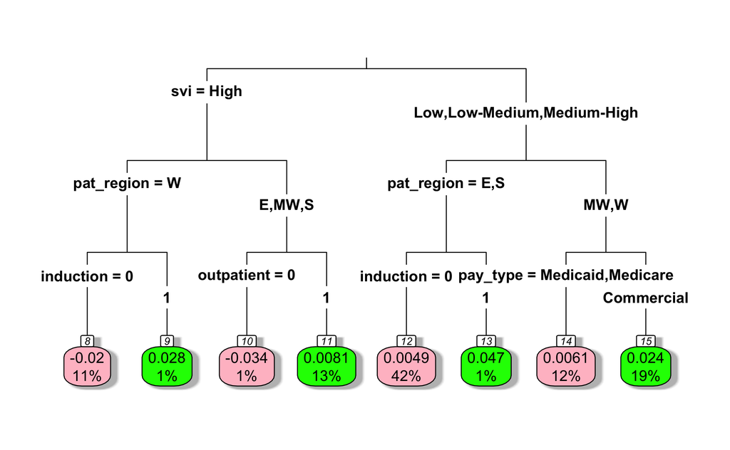

```r
library(rpart)
library(rpart.plot)
rpart.plot(
  tree_model_mhealth1,
  type = 3,
  box.palette = c("pink", "green"),  # Custom palette: pink and green
  shadow.col = "gray",
  nn = TRUE, roundint=FALSE
)
```

tree_model_mhealth, 50, 0.002, 4 simpler tree_model_mhealth, 50, 0.0015, 4 with age

saveRDS(tree_model_mhealth, file = “tree_model_mhealth1.rds”) saveRDS(tree_model_mhealth, file = “tree_model_mhealth2.rds”)

### Pay type disparities (Z = Prf(Private, Xi) - Prf (Public, Xi))

```r
predictors1<- setdiff(names(episode_model5), "discontinued")

predictors2 <- c("pat_region", "age_group", "svi", "nodrug", "alcohol", "der_sex", "telehealth", "outpatient", "bupre_tx", "hiv", "mat", "induction", "m_health")
outcome <- "discontinued"
disparity_var <- "pay_type"
```

```r
s2_result <- virtual_twins_analysis(
  dataset = episode_model5,
  outcome = outcome,
  disparity_var = disparity_var,
  predictors1 = predictors1,
  predictors2 = predictors2
)
data_for_tree <- s2_result$data_for_tree
formula <- s2_result$formula

tree_model_paytype <- rpart(
  formula,
  data = data_for_tree,
  method = "anova",
  control = rpart.control(
    minsplit = 50,  # Higher number to reduce splits
    cp = 0.01,      # Higher cp for aggressive pruning
    maxdepth = 4,   # Limit tree depth to 3 levels
    maxcompete = 0, # Prevent competing splits, to make splitting more strict
    maxsurrogate = 0 # Avoid using surrogate splits
  )
)
```

tree_model_paytype2<-readRDS(“tree_model_paytype2.rds”)

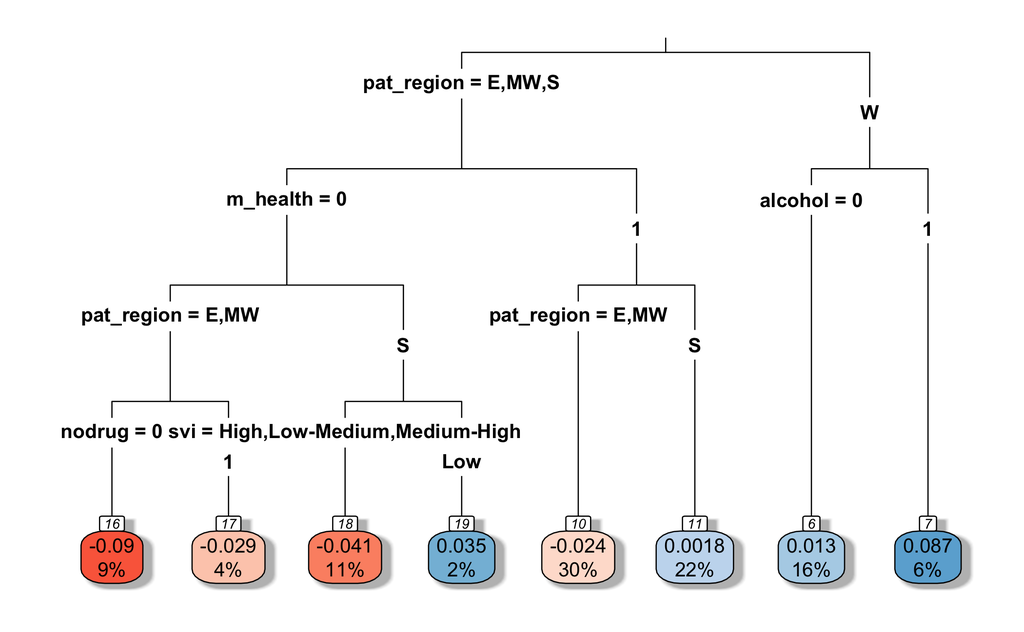

```r
rpart.plot(tree_model_paytype1, type = 3, box.palette = "RdBu", shadow.col = "gray", nn = TRUE)
```

tree_model_paytype, 75, 0.002, 3, both mhealth and psychiatric tree_model_paytype, 75, 0.003, 3 kept mhealth

saveRDS(tree_model_paytype, file = “tree_model_paytype1.rds”) # 50, 0.01, 4 #resembles more like saveRDS(tree_model_paytype, file = “tree_model_paytype2.rds”) # 75, 0.002, 3

### Age group disparities (Z = Prf(age<35, Xi)-Prf (age>=35, Xi))

```r
predictors1<- setdiff(names(episode_model7), "discontinued")

predictors2 <- c("pat_region", "pay_type", "svi", "nodrug", "alcohol", "der_sex", "telehealth", "outpatient", "bupre_tx", "hiv", "mat", "induction", "m_health", "psychiatric")
outcome <- "discontinued"
disparity_var <- "age_group"
```

```r
s2_result <- virtual_twins_analysis(
  dataset = episode_model7,
  outcome = outcome,
  disparity_var = disparity_var,
  predictors1 = predictors1,
  predictors2 = predictors2
)
data_for_tree <- s2_result$data_for_tree
formula <- s2_result$formula

tree_model_age <- rpart(
  formula,
  data = data_for_tree,
  method = "anova",
  control = rpart.control(
    minsplit = 50,  # Higher number to reduce splits
    cp = 0.007,      # Higher cp for aggressive pruning
    maxdepth = 4,   # Limit tree depth to 3 levels
    maxcompete = 0, # Prevent competing splits, to make splitting more strict
    maxsurrogate = 0 # Avoid using surrogate splits
  )
)
```

tree_model_age2<-readRDS(“tree_model_age2.rds”)

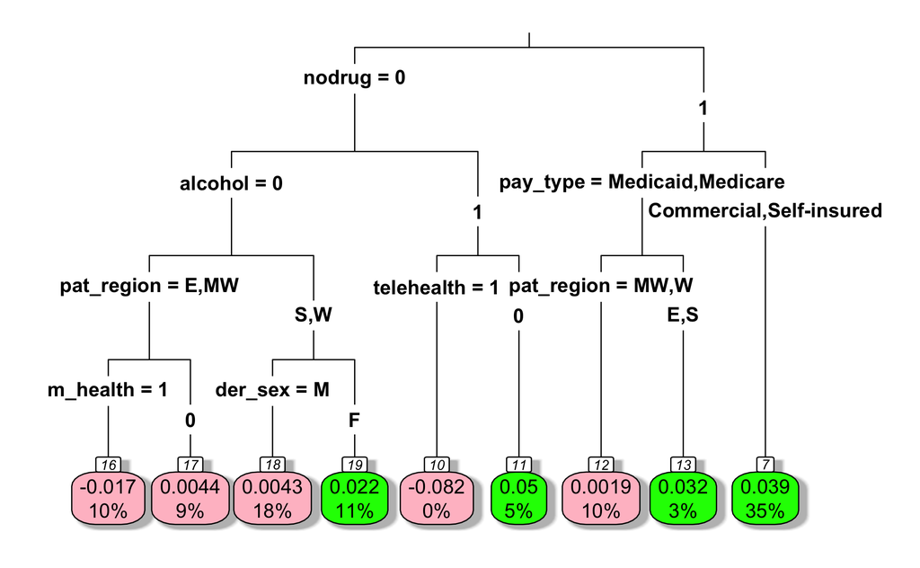

```r
#rpart.plot(tree_model_age1, type = 3, box.palette = "RdBu", shadow.col = "gray", nn = TRUE)
rpart.plot(
  tree_model_age2,
  type = 3,
  box.palette = c("pink", "green"),  # Custom palette: pink and green
  shadow.col = "gray",
  nn = TRUE, roundint=FALSE
)
```

saveRDS(tree_model_age, file = “tree_model_age1.rds”) saveRDS(tree_model_age, file = “tree_model_age2.rds”) #50, 0.007, 4